# R Environment and Syntax

Intro2R crash course: Session 1 of 2

Author: [Song, Xiao Ping](https://xp-song.github.io)

Last updated on 2022-10-18

# 1 General Syntax

## 1.1 Operators in R

### 1.1.1 Arithmetic

- `+` `-` `*` `/`
- `^` or `**` Exponentiate
- `%%` Modulus (e.g. `5%%2` = 1)
- `%/%` Integer division (e.g. `23%/%5` = 4)

### 1.1.2 Logical

- `<` `<=` `>` `>=`
- `==` Exactly equal (e.g. `1e3 == 1*10^3`; `1e-3 == 1*10^-3`)
- `!=` Not equal
- `!x` Not x
- `x|y` x OR y
- `x&y` x AND y

### 1.1.3 Other

- `1:10` creates a sequence:

```
##  [1]  1  2  3  4  5  6  7  8  9 10
```

- `$` Extract elements by name from a named list (colnames for tabular data)

```r
x <- list(a=1, b=2, c=3)
x$b
```

```
## [1] 2
```

### 1.1.4 Subsetting

- Use square brackets `[ ]`
- Double square brackets `[[]]` are used to extract elements of list/dataframe (similar to using `$` in `dataframe$colname`)
- If dataset has 2 dimensions (i.e. tabular format), always specify row then column number
- Examples:
  - `x[5]` 5th element in vector `x`
  - `df[3,5]` Element in 3rd row & 5th col of dataframe `df`
  - `df[c(3,5),]` Row 3 & 5, all cols of dataframe `df`
  - `df[3:5,]` Row 3,4 & 5, all cols of dataframe `df`
  - `df[-2,]` Everything except row 2 of dataframe `df`
  - `df[df$gender=='F' & df$age > 65, ]` Subset in combination with other operators

## 1.2 Variables

- Named objects used to store data
- Naming should be consistent/clear
  - Case sensitive, no numbers/symbols/whitespace
  - E.g. treeHeight_m, species_count
- **Data types:** Numeric, integer, character, logical (T/F) or complex

```r
#numeric data
x <- 4
x <- (4+5)/2

#character data
x <- "hello"
```

# 2 Data Structures

## 2.1 Vectors

- Linear/sequential collection of data of the *same* type
- Coercion occurs if different types are mixed
- Asking and coercion can be done manually to change the vector (data) type
- Note that the `c()` function combines (concatenates) its arguments to form a vector

```r
#numeric vectors
x <- c(1,3,5,6)
x <- 1:5
x <- seq(1,5,1)
x <- vector("numeric", length=10)
num_vec <- c(TRUE, 2) #in R, TRUE=1, FALSE=0
is.numeric(num_vec)

#character vectors
x <- c("hello", "a", "b", "c")
x <- c(1.7, "a")
char_vec <- c("a", TRUE) #'TRUE' turned from logical to character
is.character(char_vec)

x <- as.character(num_vec) #coercion from numeric to character
x
```

## 2.2 Lists

- Consist of different elements (i.e. variables/vectors) that can be of *different types*
- Elements in a list are indexed with [[]], individual items are in []
- Functions only be applied to vectors, not lists!

```r
mylist <- list(num_vec, char_vec, 1.783, 5L, "hello") #add L suffix if you explicitly want integers
mylist
is.list(mylist) #asking
```

## 2.3 Factors

- Used to represent data with limited, discrete categories (i.e. categorical, ordinal, or even binary)
- Can be coded as character or numeric
- Some examples:
  - Blue, Black, Brown (eye color)
  - High, Medium, Low (3, 2, 1)
  - Strongly disagree, disagree, neutral, agree, strongly agree (-2:2)
  - Male, Female (1, 2)

```r
x <- factor(c("SA", "D", "A", "A", "SA", "Neutral", "SD"))
x

#define order (default is alphabetical)
x <- factor(c("SA", "D", "A", "A", "SA", "Neutral", "SD"), levels = c("SD", "D", "Neutral", "A", "SA"))
x

unclass(x) #show as numbers, with "levels" attribute showing actual text
```

## 2.4 Matrices

- Tabular data in rectangular format (2D array with rows & columns)
- Data must be of the *same* type!
- More memory efficient than dataframes

```r
m <- matrix(1:12, nrow = 4)
m #data goes in by columns in default mode

dim(m) #dimensions: no. of rows & cols
dimnames(m)
dimnames(m) <- list(c("Tom", "Dick", "Harry", "Me"), c("Blue", "White", "Red")) #add names to row/cols

#size comparisons
object.size(m) # 264 bytes
d <- as.data.frame(m) #convert to dataframe
object.size(d) # 1032 bytes
```

## 2.5 Dataframes

- Tabular data in rectangular format (2D array with rows & columns)
- Columns are vectors/lists of similar length, representing different variables
- Each row represents a data entry
- Import tabular data as dataframes using `read.table()` family of functions  
  (i.e. `read.csv()`, `read.delim()`)

```r
#data.frame() manually create df

ozone <- read.csv("../data/ozone_data.csv") # headers in first row (default setting)
is.data.frame(ozone) #check attribute
head(ozone) #view first few rows only

dim(ozone) #dimensions: no. of rows & cols
dimnames(ozone) #row & col names
names(ozone) #col names, also can use 'colnames(ozone)'
rownames(ozone)

#extract columns with '$'
ozone$rad
ozone$temp
```

# 3 Functions

- Many functions available in packages
- Functions break our code into simpler parts/modules, which helps improve readability
- You can create your own (user-defined) functions, and edit existing ones
- Inputs to a function include variables and arguments
  - Look up details with `?functionname` (e.g. `?read.csv`)

## 3.1 Common functions

**Basic calculation**

- `log(x)` Log base e of x (natural)
- `log10(x)` Log base 10 of x
- `log(x,n)` Log base n of x
- `exp()` Exponential
- `sqrt()` Square root
- `sin()`; `cos()`; `tan()`
- `factorial()`

**Create vectors**

- `seq(a,b,c)` A vector with elements a:b, with step magnitudes of c (e.g. Days in a year is `seq(1,365,1)`)
- `rep(a,b)` A vector with a repeated b times

**Rounding of numeric vectors**

- `round(x, digits=0)` 0 decimal places for x
- `signif(x, digits=2)` x rounded to 2 sig. fig.
- `floor(x)` Largest *integer* greater than corresponding elements of x (round down)
- `ceiling(x)` Smallest *integer* greater than corresponding elements of x (round up)
- `abs(x)` absolute value

**Summary statistics of vectors/tabular data**

- `mean(x)`
- `median(x)`
- `var(x)` Variance
- `max(x)` Max element
- `min(x)` Min element
- `range(x)` Min & max elements
- `quantile(x)` Returns vector with the quantiles of x
- `nrow()` Number of rows in tabular data
- `ncol()` Number of columns in tabular data
- `length(x)` Number of elements in x (same result as `ncol()` of dataframe)

**Calculation for vectors/matrices**

- `sum(x)` sums elements
- `prod(x)` product of the elements
- `colMeans(x)`
- `rowMeans(x)`
- `colSums(x)`
- `rowSums(x)`

**Manipulation of vectors/matrices**

- `rank(x)` Vector of the ranks of the values in x (increasing order)
- `sort(x)` Produce another vector with elements in increasing order
- `sample(x, n, replace=T)` Sample a vector n times with replacement Adding rows/Creating matrices by joining vectors (e.g. adding the vectorA <- c(1,1,1))
- `cbind(x, y)` Bind x & y as columns to form new matrix
- `rbind(x, y)` Bind x & y as rows to form new matrix

**Plotting functions**

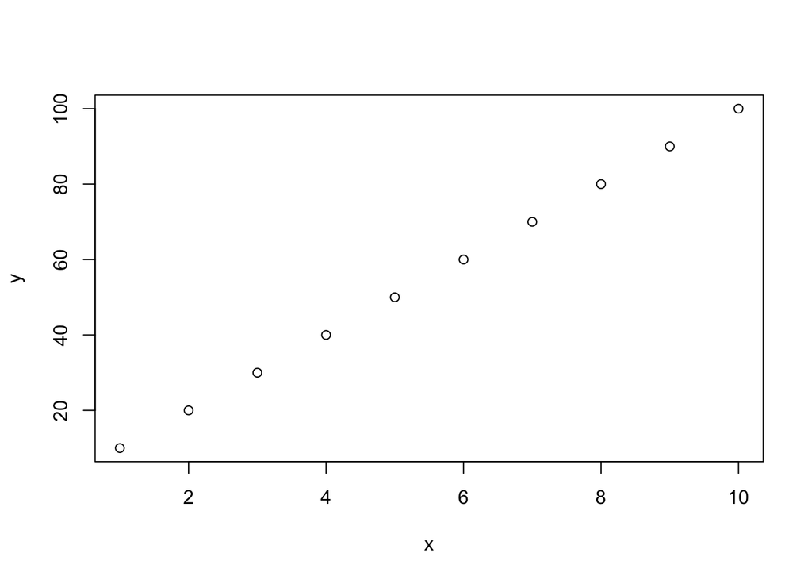

```r
x <- seq(1,10)
y <- x*10
plot(x,y)
```

## 3.2 User-defined functions

- You define your own inputs and outputs
- General structure: `functionname <- function(inputs){calculations, output}`
- E.g. Calculate GPA from `grades.csv` using the following formula:

$$\frac{ \sum_{i=1}^{n}gradepoint_i \times credits_i}{
\sum_{i=1}^{n}credits_i}$$

```r
grades <- read.csv("../data/grades.csv")
grades
```

```
##     subject grade grade_point credits
## 1      Math     A         4.5       5
## 2   English     B         3.5       5
## 3 Economics     C         2.0       4
## 4  Mandarin    B+         4.0       5
## 5     Music     F         1.0       0
## 6   History    C+         2.5       5
## 7   Intro2R    A+         5.0       1
```

```r
sum(grades$grade_point * grades$credits) / sum(grades$credits) #vectorised multiplication
```

Create a function named `scorer` that:

- Takes a dataframe as input
- Outputs a calculation based on the specific colnames `grade_point` and `credits`

```r
scorer <- function(x=grades){
  sum(x$grade_point*x$credits) / sum(x$credits)
  }

#use function
scorer(grades)
```

## 3.3 User-defined loops

- Loop functions repeat a code `i` number of times
- Various types of loops:
  - `for` Execute a fixed number of times
  - `if` or `ifelse` Execute on specific conditions
  - `while` Execute while a condition is true (be careful of infinite loops)
  - `repeat` Execute an infinite loop
- Actions within a loop:
  - `break` Break execution
  - `next` Skip an iteration
  - `return` Exit a function
- Loops can be nested! (i.e. loop within a loop)
- Perform subsetting to extract/write calculations within loops
  - E.g. `x[i]` refers to the `i`th element in vector `x`

**Example of a FOR loop**

- Find the range of values for each numeric column in `grades`

```r
colrange <- list() # create empty list

for(i in 3:ncol(grades)){ #iterate across numeric cols 3-4 (2 times)
  colrange[[i-2]] <- range(grades[,i])
}

names(colrange) <- names(grades)[3:4] # convert to named list

colrange
```

```
## $grade_point
## [1] 1 5
##
## $credits
## [1] 0 5
```

**Example of FOR and IF loop:**

- The passing grade is >=2. Add a new column that indicates if subject pass/fail (LOGICAL data type)

```r
grades$pass <- NULL # new col

for(i in 1:nrow(grades)){ #iterate across each row (7 times)

  if(grades$grade_point[i] >= 2){
    grades$pass[i] <- TRUE
    } else {
      grades$pass[i] <- FALSE
    }
}

grades
```

```
##     subject grade grade_point credits  pass
## 1      Math     A         4.5       5  TRUE
## 2   English     B         3.5       5  TRUE
## 3 Economics     C         2.0       4  TRUE
## 4  Mandarin    B+         4.0       5  TRUE
## 5     Music     F         1.0       0 FALSE
## 6   History    C+         2.5       5  TRUE
## 7   Intro2R    A+         5.0       1  TRUE
```

## 3.4 Loop functions in base R

- `lapply(x, FUN)`: Apply a function on each element of `x`
  - Returns a *list* (always)
- `sapply(x, FUN)` Similar to `lapply` but tries to simplify results
  - Returns a *vector* if result is a list where every element is length = 1
  - Returns a *matrix* if result is a list where every element is of the same length (>1)
  - In all other scenarios, a *list* is returned
- `apply(x, MARGIN, FUN)` Apply a function to tabular data by rows (`1`), cols (`2`), or both `c(1,2)`
- `tapply(x, index, FUN)` Apply a function over subsets of a vector
- `mapply()` Multivariate version of `lapply`

**E.g. `lapply()`**

- Find the range of values for each numeric column in `grades` (similar to user-defined FOR loop example above!)

```r
lapply(grades[,3:4], range)
```

```
## $grade_point
## [1] 1 5
##
## $credits
## [1] 0 5
```

# 4 Useful Resources

**Online tutorials:**

- [R for Data Science](https://r4ds.had.co.nz)
- [Quick R](https://www.statmethods.net)
- [R for cats](https://www.rforcats.net) (blog post)
- [swirl](https://swirlstats.com) (good for practice)

**Online courses:**

- [Introuction to R](https://www.datacamp.com/courses/free-introduction-to-r) by Datacamp
- [R Programming](https://www.coursera.org/learn/r-programming) by Coursera

**Online Q&A:**

- [Stack Overflow](https://stackoverflow.com/questions/5963269/how-to-make-a-great-r-reproducible-example?rq=1)
- Remember to check your `sessionInfo()` when troubleshooting!

**R Markdown:**

- [Basic formatting](https://rmarkdown.rstudio.com/authoring_basics.html)
- [Cheatsheet](https://www.rstudio.com/wp-content/uploads/2015/02/rmarkdown-cheatsheet.pdf)

**Others:**

- [How to use R/RStudio from an external drive](https://github.com/ClaudiaBrauer/A-very-short-introduction-to-R/blob/master/documents/Portable_versions_of_R_and_RStudio.pdf) (i.e. if you don’t have admin rights to install software)

Copyright © 2022 Song, Xiao Ping